# Estudios de Informática, Multimedia y Telecomunicaciones

# Tipología y ciclo de vida de los datos - PRA2

Autor: Enrique Vera Ortiz - Carlos Pintor

Diciembre 2021

# 1 Descripción del dataset

El Dataset responde a un interés común de ambos alumnos por el estudio del consumo eléctrico en el contexto, cada día más popular, del cambio climático y los Objetivos de Desarrollo Sostenible..

En la práctica 1, ya se comentó el interés de los autores del ejercicio especialmente en el objetivo 7 de generación de energía limpia y asequible.

[figure not shown]

En el anterior ejercicio se estudiaba la generación de consumo eléctrico así como el consumo, las diferentes fuentes de energía y su relación variables atmosféricas. El objetivo original de esta práctica era continuar con el mismo set de datos, sin embargo, por motivos pedagógicos hemos decidido utilizar un set de datos que nos diera más posibilidades de trabajo (mayor muestra, valores missing y variables categóricas).

En esta ocasión se ha optado por seleccionar un set de datos del portal Kaggle. El objetivo de este dataset es el de encontrar maneras de mejorar la eficiencia energética de una serie de inmuebles gracias al conocimiento de las variables que inciden en el consumo eléctrico.

Este dataset contiene información sobre el consumo eléctrico en un gran número de edificios a lo largo de un periodo de tres años. Igualmente, se seleccionan una serie de variables recogidas en el mismo momento como la temperatura del aire, la dirección y velocidad del viento, el tamaño del edificio.

La variable considerada como target es por tanto el consumo eléctrico y las variables independientes son las siguientes:

- primary_use: Uso principal del inumeble. Variable categórica que recoge si su uso principal es la vivienda, la educación, la sanidad, oficinas, edificios públicos…
- year_built: Año de construcción del edificio (año)
- floor_count: Número de pisos del edificio (número)
- air_temperature: Temperatura del aire (medido en celsius)
- cloud_coverage: Porcentaje del cielo cubierto por nubes (medido en porcentaje)
- dew_temperature: Es una medición de la temperatura relacionada con la humedad y la presión atmosférica (medido en celsius)
- precip_depth_1_hr: Precipitación por horas (medido en mililitros)
- sea_level_pressure: Nivel de presión (medido en milibares)
- wind_direction: Dirección del viento (de 0 a 360 grados)
- wind_speed: Velocidad del viento (medido en metros por segundo)

# 2 Integración y selección de datos a analizar

La información originalmente está repartida en tres bases de datos diferentes:

- train.csv: Que contiene toda la información relacionada con la medición de la temperatura utilizada junto con un id_building (identificador del edificio).
- building_meta.csv: Con información del edificio en cuanto a año de construcción, tamaño, número de plantas etc con el building_id (identificador del edificio) y el site_id (identificador climatológico).
- weather.csv: Contiene toda la información meteorológica como la temperatura, la presión, la velocidad y dirección del viento… asíc omo un site_id (identificador climatológico).

Con el fin de trabajar con la base de datos se unifican los tres ficheros en uno (energy.csv) de la siguiente manera:

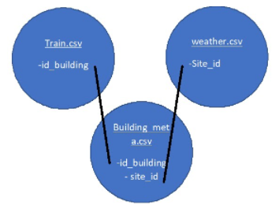

## 2.1 Código que se ha utilizado para integrar los datos

Lectura de los tres ficheros:

*train = pd.read_csv(‘C:/Users/c_pin/Downloads/ashrae-energy-prediction/train.csv’,sep=‘,’)*

*building_meta = pd.read_csv(‘C:/Users/c_pin/Downloads/ashrae-energy-prediction/building_metadata.csv’,sep=‘,’)*

*weather_train= pd.read_csv(‘C:/Users/c_pin/Downloads/ashrae-energy-prediction/weather_train.csv’,sep=‘,’)*

Cruzar los tres ficheros:

*weather_building = pd.merge(weather_train,building_meta, how=‘inner’,on=‘site_id’)*

*df_initial = pd.merge(weather_building,train, how=‘inner’,on=[‘building_id’,‘timestamp’])*

Exportar los tres ficheros

*df_initial.to_csv(‘C:/Users/c_pin/Downloads/ashrae-energy-prediction/energy.csv’,index=False, header=True)*

Para reducir la base de datos nos quedaremos únicamente con el tipo de medida 0: electricidad

*df_tiempo_electricity = df_tiempo[df_tiempo$meter==0,]*

Lectura y carga del fichero CSV

```r
df_tiempo = read.csv('./energy.csv',sep=',')
```

# 3 Limpieza de los datos

Las variables que se han extraído son las siguientes:

```r
names(df_tiempo)
```

```
##  [1] "site_id"            "timestamp"          "air_temperature"
##  [4] "cloud_coverage"     "dew_temperature"    "precip_depth_1_hr"
##  [7] "sea_level_pressure" "wind_direction"     "wind_speed"
## [10] "building_id"        "primary_use"        "square_feet"
## [13] "year_built"         "floor_count"        "meter"
## [16] "meter_reading"
```

Para reducir la base de datos nos quedaremos únicamente con el tipo de medida 0: electricidad

```r
df_tiempo_electricity = df_tiempo[df_tiempo$meter==0,]
```

Seleccionamos las variables que realmente pueden tener sentido

```r
var_select = c("air_temperature","cloud_coverage","dew_temperature","precip_depth_1_hr","sea_level_pressure",
               "wind_direction","wind_speed","primary_use","square_feet","year_built","floor_count",
               "meter_reading")
df_tiempo_select = df_tiempo_electricity[var_select]
```

Analizamos el tipo de datos y como queda el dataframe final

```r
sapply(df_tiempo_select, class)
```

```
##    air_temperature     cloud_coverage    dew_temperature  precip_depth_1_hr
##          "numeric"          "numeric"          "numeric"          "numeric"
## sea_level_pressure     wind_direction         wind_speed        primary_use
##          "numeric"          "numeric"          "numeric"        "character"
##        square_feet         year_built        floor_count      meter_reading
##          "integer"          "numeric"          "numeric"          "numeric"
```

```r
dim(df_tiempo_select)
```

```
## [1] 12017408       12
```

## 3.1 ¿Los datos contienen ceros o elementos vacíos? ¿Cómo gestionarías cada uno de estos casos?

Analizamos la existencia de valores missing por campo

```r
sapply(df_tiempo_select, function(x) sum(is.na(x)))
```

```
##    air_temperature     cloud_coverage    dew_temperature  precip_depth_1_hr
##               3823            5286150               5589            2470177
## sea_level_pressure     wind_direction         wind_speed        primary_use
##             974881             635213              23293                  0
##        square_feet         year_built        floor_count      meter_reading
##                  0            6462735            9058669                  0
```

```r
var_select = c("air_temperature","dew_temperature","sea_level_pressure",
               "wind_direction","wind_speed","primary_use","square_feet","meter_reading")
df_tiempo_select = df_tiempo_select[var_select]
sapply(df_tiempo_select, function(x) sum(is.na(x)))
```

```
##    air_temperature    dew_temperature sea_level_pressure     wind_direction
##               3823               5589             974881             635213
##         wind_speed        primary_use        square_feet      meter_reading
##              23293                  0                  0                  0
```

Para no eliminar los datos, se podrían imputar de diferentes formas como aplicando la media general de cada variable o en función de la frecuencia. En este caso se decide imputar estos valores vacíos con el método kNN de la librería VIM, se trata de un algoritmo supervisado que clasifica cada dato nuevo en el grupo que corresponda, según tenga k vecinos más cerca de un grupo o de otro.

Se seleccionan 50K casos con un muestreo aleatorio para que no se produzcan problemas de rendimiento del sistema.

```r
df_sample_tiempo = df_tiempo_select[sample(nrow(df_tiempo_select), 50000), ]

write.csv(df_sample_tiempo, file ='./energy_sample.csv', sep= ',')
df_sample_tiempo = read.csv('./energy_sample.csv',sep=',')



# Se obtienen de nuevo los valores missing
sapply(df_sample_tiempo, function(x) sum(is.na(x)))
```

```
##                  X    air_temperature    dew_temperature sea_level_pressure
##                  0                 20                 27               3959
##     wind_direction         wind_speed        primary_use        square_feet
##               2685                 91                  0                  0
##      meter_reading
##                  0
```

Se imputan los valores NA por KNN

```r
df_sample_tiempo$air_temperature = kNN(df_sample_tiempo)$air_temperature
df_sample_tiempo$dew_temperature = kNN(df_sample_tiempo)$dew_temperature
df_sample_tiempo$sea_level_pressure = kNN(df_sample_tiempo)$sea_level_pressure
df_sample_tiempo$wind_direction = kNN(df_sample_tiempo)$wind_direction
df_sample_tiempo$wind_speed = kNN(df_sample_tiempo)$wind_speed
```

Por último, se valida que se hayan cargado correctamente los valores missing.

```r
sapply(df_sample_tiempo, function(x) sum(is.na(x)))
```

```
##                  X    air_temperature    dew_temperature sea_level_pressure
##                  0                  0                  0                  0
##     wind_direction         wind_speed        primary_use        square_feet
##                  0                  0                  0                  0
##      meter_reading
##                  0
```

## 3.2 Identificación y tratamiento de valores extremos

Se representan gráficamente los boxplot para cada una de las variables marcando en rojo los outliers:

- air_temperature:

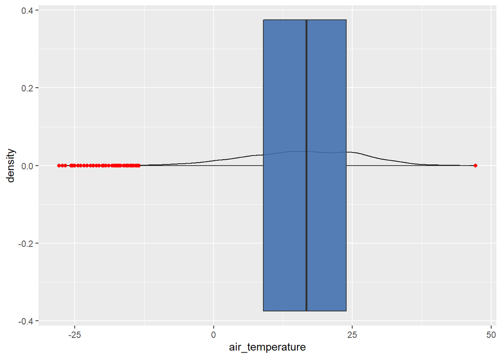

```r
ggplot(data = df_sample_tiempo, aes(x = air_temperature)) + geom_density()+
       geom_boxplot(fill = "#4271AE",
                    outlier.colour = "red",
                    alpha = 0.9)
```

- dew_temperature:

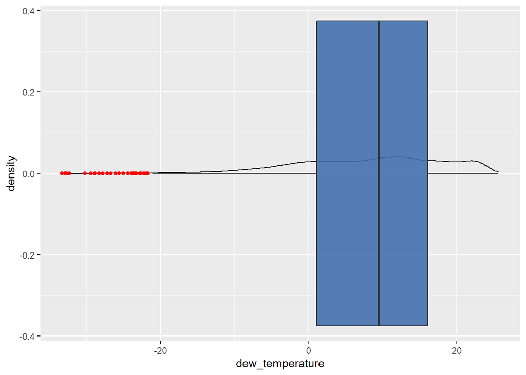

```r
ggplot(data = df_sample_tiempo, aes(x = dew_temperature)) + geom_density()+
       geom_boxplot(fill = "#4271AE",
                    outlier.colour = "red",
                    alpha = 0.9)
```

- sea_level_pressure:

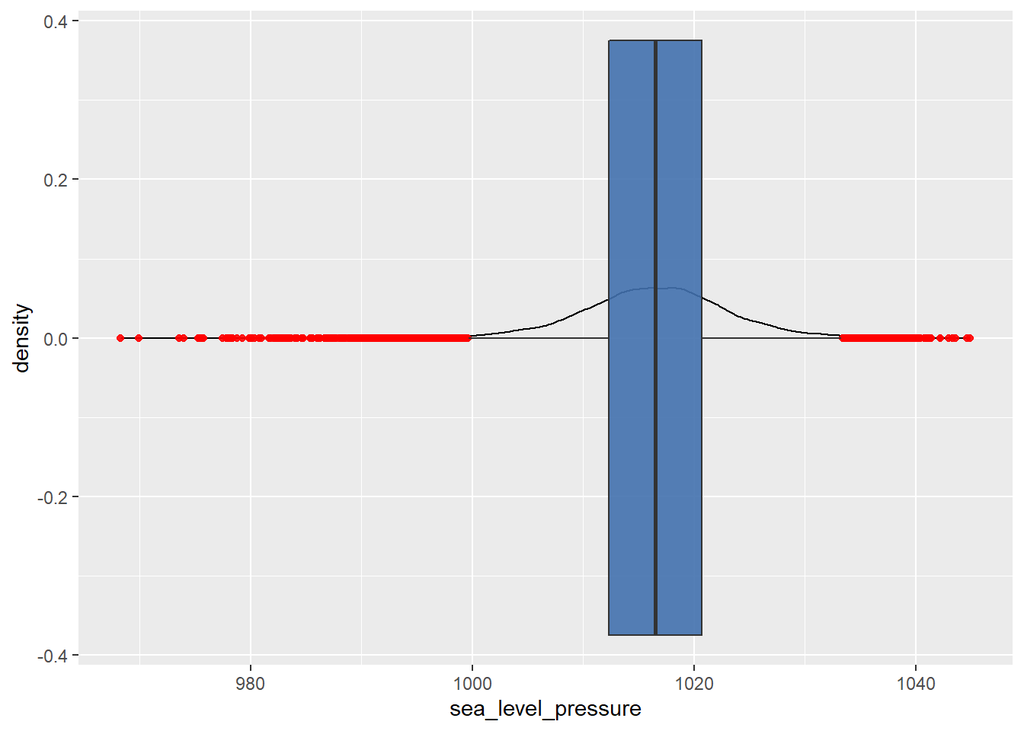

```r
ggplot(data = df_sample_tiempo, aes(x = sea_level_pressure)) + geom_density()+
       geom_boxplot(fill = "#4271AE",
                    outlier.colour = "red",
                    alpha = 0.9)
```

- wind_direction:

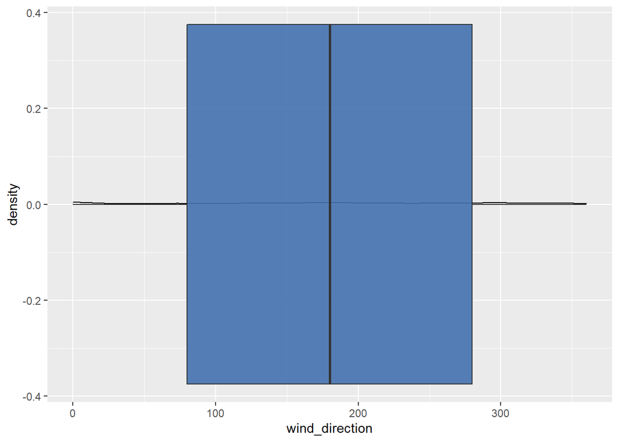

```r
ggplot(data = df_sample_tiempo, aes(x = wind_direction)) + geom_density()+
       geom_boxplot(fill = "#4271AE",
                    outlier.colour = "red",
                    alpha = 0.9)
```

- wind_speed:

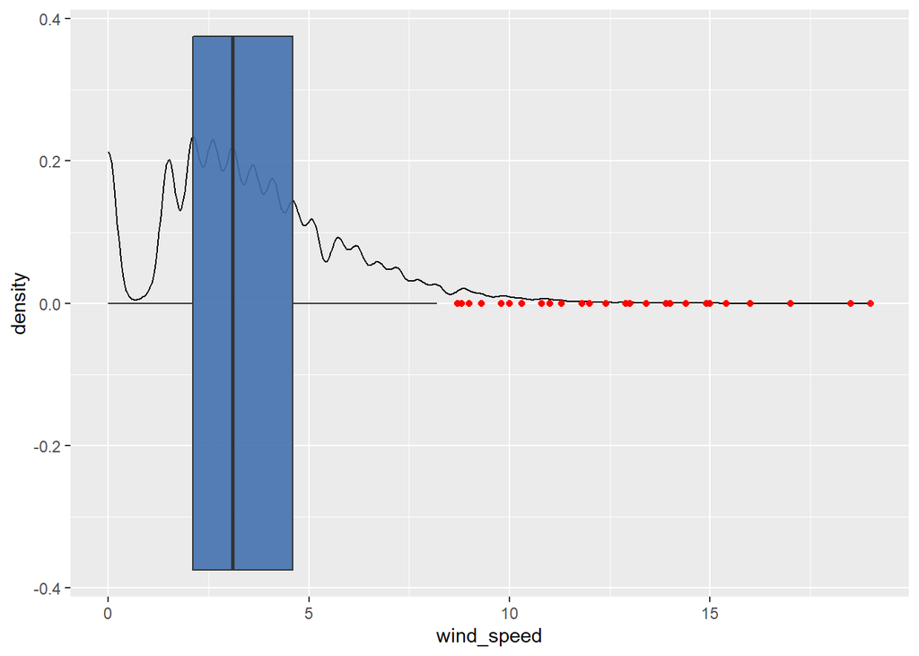

```r
ggplot(data = df_sample_tiempo, aes(x = wind_speed)) + geom_density()+
       geom_boxplot(fill = "#4271AE",
                    outlier.colour = "red",
                    alpha = 0.9)
```

- square_feet:

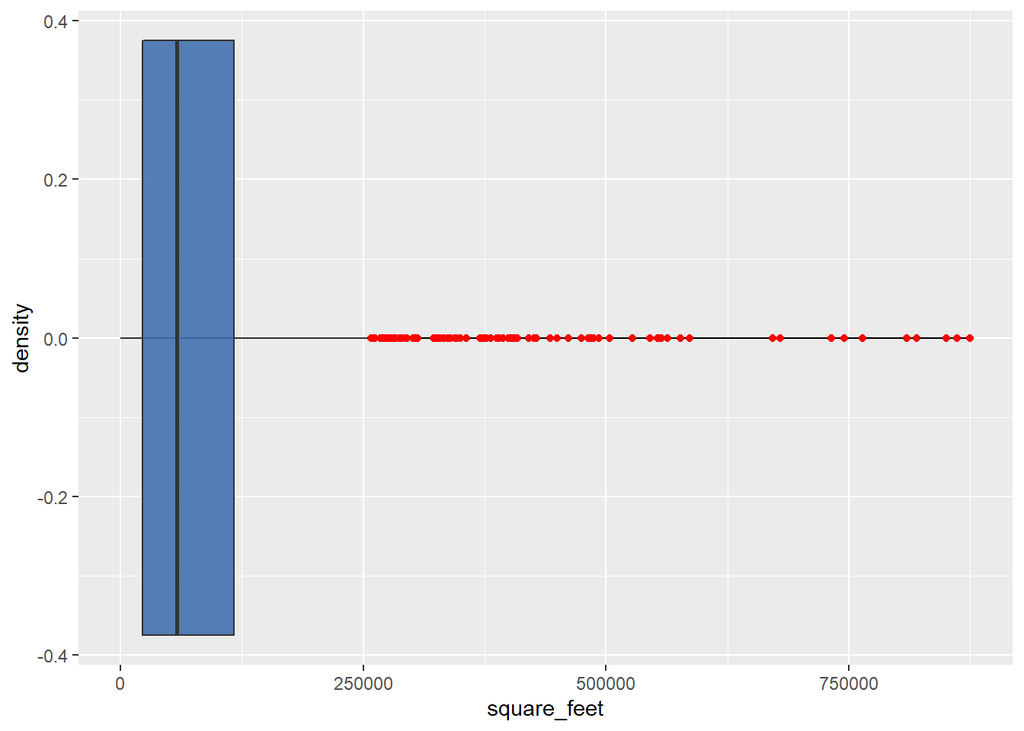

```r
ggplot(data = df_sample_tiempo, aes(x = square_feet)) + geom_density()+
       geom_boxplot(fill = "#4271AE",
                    outlier.colour = "red",
                    alpha = 0.9)
```

- meter_reading:

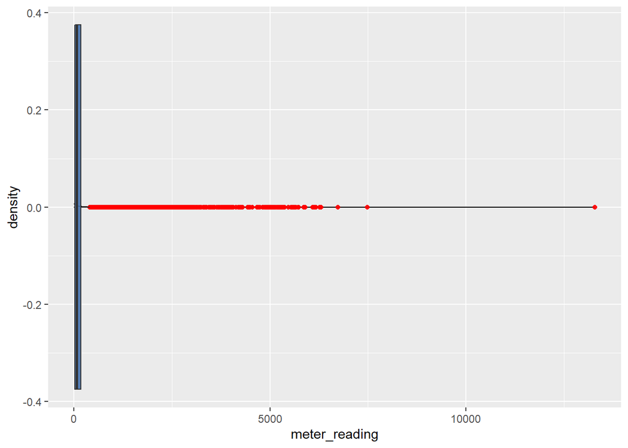

```r
ggplot(data = df_sample_tiempo, aes(x = meter_reading)) + geom_density()+
       geom_boxplot(fill = "#4271AE",
                    outlier.colour = "red",
                    alpha = 0.9)
```

Tras observar los valores, se eliminan aquellos registros cuya temperatura del aire es superior a 50ºC o inferior a -25ºC dado que se consideran temperaturas muy extremas difíciles de conseguir.

```r
df_sample_tiempo = df_sample_tiempo[df_sample_tiempo$air_temperature<=50 && df_sample_tiempo$air_temperature>=-25,]
df_sample_tiempo = df_sample_tiempo[df_sample_tiempo$dew_temperature<=50 && df_sample_tiempo$dew_temperature>=-25,]
df_sample_tiempo = df_sample_tiempo[df_sample_tiempo$square_feet<=500000,]
df_sample_tiempo = df_sample_tiempo[df_sample_tiempo$meter_read<=1000,]
```

Además, se comprueban posibles valores extremos en la variable categórica primary_use

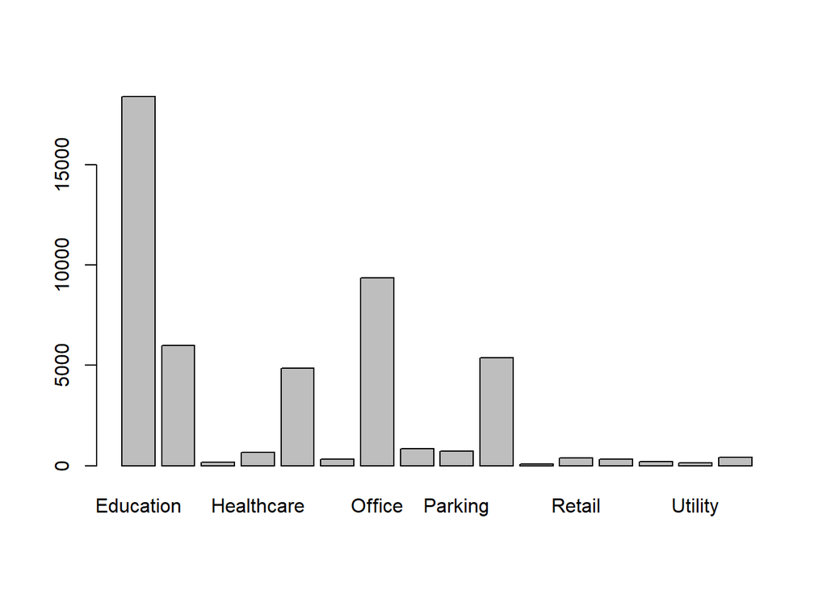

```r
barplot(table(df_sample_tiempo$primary_use))
```

```r
aggregate(df_sample_tiempo$primary_use, by=list(df_sample_tiempo$primary_use), FUN=length)
```

```
##                          Group.1     x
## 1                      Education 18393
## 2  Entertainment/public assembly  6002
## 3         Food sales and service   180
## 4                     Healthcare   654
## 5            Lodging/residential  4849
## 6       Manufacturing/industrial   341
## 7                         Office  9373
## 8                          Other   853
## 9                        Parking   720
## 10               Public services  5372
## 11             Religious worship    91
## 12                        Retail   396
## 13                      Services   328
## 14            Technology/science   208
## 15                       Utility   131
## 16             Warehouse/storage   426
```

Se puede confirmar que no hace falta eliminar ningún valor extremo para esta variable

# 4 Análisis de los datos

## 4.1 Selección de los grupos de datos que se quieren analizar/comparar (planificación de los análisis a aplicar).

El grupo de datos que se va a utilizar ya se ha seleccionado en los puntos anteriores de limpieza de datos.

## 4.2 Comprobación de la normalidad y homogeneidad de la varianza.

```r
for (i in names(df_sample_tiempo)){
  if(is.numeric(df_sample_tiempo[,i])){
    test=lillie.test(df_sample_tiempo[,i])
    print(paste0("El p valor de la variable " , i, ' es: ',test$p.value))
  }
}
```

```
## [1] "El p valor de la variable X es: 0"
## [1] "El p valor de la variable air_temperature es: 1.144675075153e-193"
## [1] "El p valor de la variable dew_temperature es: 0"
## [1] "El p valor de la variable sea_level_pressure es: 1.02398251140526e-96"
## [1] "El p valor de la variable wind_direction es: 0"
## [1] "El p valor de la variable wind_speed es: 0"
## [1] "El p valor de la variable square_feet es: 0"
## [1] "El p valor de la variable meter_reading es: 0"
```

Tal y como se puede observar, los p valor tras aplicar el test de normalidad (Kolmogorov-Smirnov) ninguna de las variables tiene una distribución normal. Para ser normal, el p valor tendría que ser superior a 0.05.

A continuación, se hace un test de homocedasticidad para la variable categórica primary_use con la variable target meter_reading que indica la medición del consumo.

```r
fligner.test(meter_reading ~ primary_use, data = df_sample_tiempo)
```

```
##
##  Fligner-Killeen test of homogeneity of variances
##
## data:  meter_reading by primary_use
## Fligner-Killeen:med chi-squared = 4531.7, df = 15, p-value < 2.2e-16
```

El resultado es que la varianza no es constante entre los diferentes niveles de la variable primary_use.

## 4.3 Analisis de correlaciones

Realizamos un análisis de correlaciones de las variables numéricas:

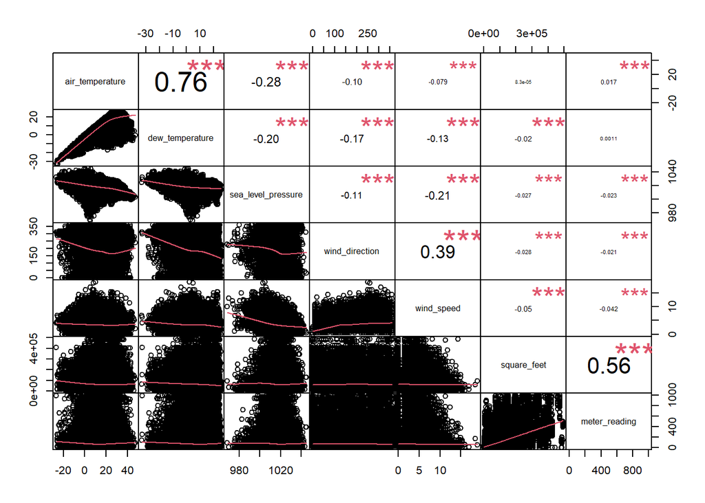

```r
columns <- c("air_temperature","dew_temperature","sea_level_pressure","wind_direction",
  "wind_speed","square_feet","meter_reading")
df_sample_tiempo_numeric = df_sample_tiempo[columns]

chart.Correlation(df_sample_tiempo_numeric, histogram = FALSE, method = "pearson")
```

Existe una alta colinealidad entre las variables “air temperature” y “dew temperature”, nos quedamos con la primera ya que tiene una mayor correlación con la variable target “meter reading”

Nos llama la atención que la variable temperatura (en sus dos formatos) apenas tenga correlación con la variable consumo ya que cabría esperar que tuviera forma de “U” en el caso de que se utilizara la electricidad para calentar y enfriar un edificio o ascendente si sólo se utilizara para enfriarlo.

Por último, decidimos eliminar la variable “wind direction” ya que además de carecer de sentido desde el punto de vista teórico (aumentar el consumo en función de la dirección del viento), apenas vemos relación con la variable target.

## 4.4 ¿Existe un mayor consumo de energía cuando la temperatura del aire supera los 21 grados?

Se considera la temperatura de confort en un ser humano cuando no supera los 21 grados. A partir de esta temperatura cabría esperar un comportamiento habitual por el que se realice un mayor consumo energético.

Nos planteamos por tanto la siguiente hipótesis: El consumo energético de un edificio es de media significativamente mayor cuando la temperatura del aire es superior a 21 grados que cuando es inferior.

Establecemos por tanto la hipótesis nula de que la media en los inumebles con temperatura menor a 21 grados es igual que aquellos en que es mayor

Establecemos la hipótesis alternativa de que esta media no es igual (en concreto es mayor).

H0: $\mu_1-\mu_2=\delta_0$

H1: $\mu_1-\mu_2\gt \delta_0$

Para contrastar la hipótesis utilizamos la variable temperatura y generamos dos tramos de valores: menor a 21 y mayor a 21 y realizamos calculamos el estadístico de diferencia de medias para dos muestraS.

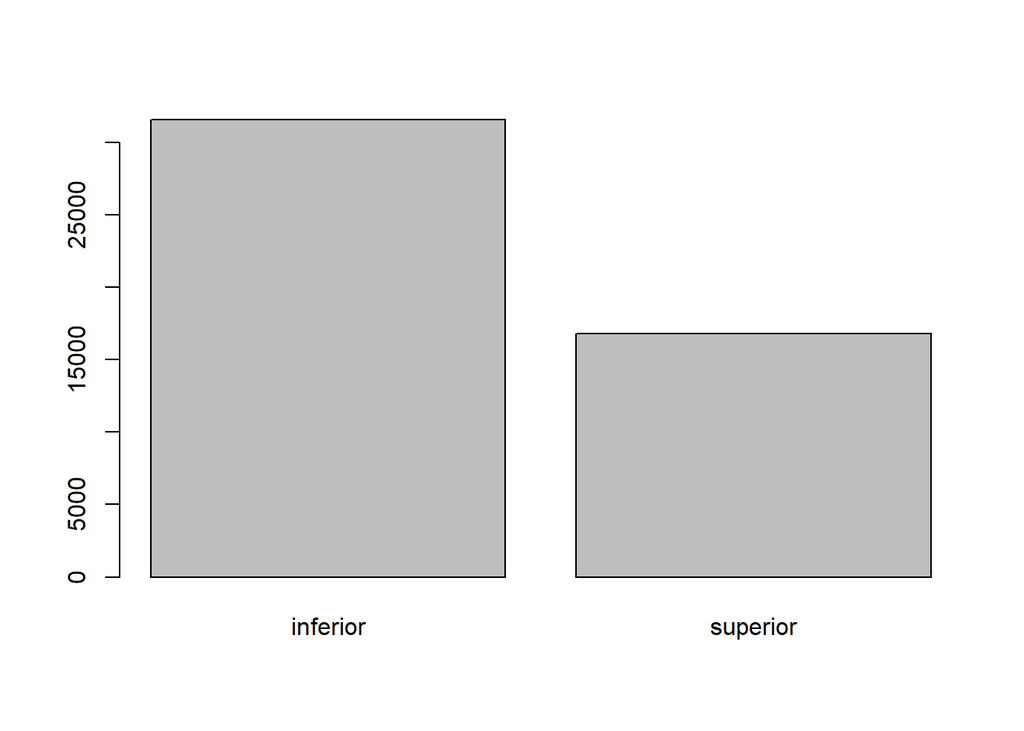

```r
df_sample_tiempo_numeric$temp_superior = ifelse(df_sample_tiempo_numeric["air_temperature"]>=21,"superior", "inferior")
barplot(table(df_sample_tiempo_numeric$temp_superior))
```

```r
df_sample_tiempo_numeric.alta_temperatura = df_sample_tiempo_numeric[df_sample_tiempo_numeric$temp_superior=="superior",]$meter_reading
df_sample_tiempo_numeric.baja_temperatura = df_sample_tiempo_numeric[df_sample_tiempo_numeric$temp_superior=="inferior",]$meter_reading

t.test(df_sample_tiempo_numeric.alta_temperatura ,df_sample_tiempo_numeric.baja_temperatura , alternative = "greater")
```

```
##
##  Welch Two Sample t-test
##
## data:  df_sample_tiempo_numeric.alta_temperatura and df_sample_tiempo_numeric.baja_temperatura
## t = 8.6367, df = 32937, p-value < 2.2e-16
## alternative hypothesis: true difference in means is greater than 0
## 95 percent confidence interval:
##  11.3422     Inf
## sample estimates:
## mean of x mean of y
##  132.6753  118.6647
```

Podemos afirmar con un alfa de 0.05 que el consumo cuando la temperatura es igual o superior a 21 grados es mayor que cuando la temperatura es inferior a los 21 grados.

## 4.5 Modelo de regresión lineal

Se transforma la variable categórica (primary_use) en cinco variables dicotómicas para que puedan ser usadas en modelos de regresión. Estas cinco variables se llamarán:

- educacion
- oficina
- entretenimiento
- servicios públicos
- residencial

```r
df_sample_tiempo$educacion = ifelse(df_sample_tiempo["primary_use"]=='Education', 1, 0)
df_sample_tiempo$oficina = ifelse(df_sample_tiempo["primary_use"]=='Office', 1, 0)
df_sample_tiempo$entretenimiento = ifelse(df_sample_tiempo["primary_use"]=='Entertainment/public assembly', 1, 0)
df_sample_tiempo$servicios_publicos = ifelse(df_sample_tiempo["primary_use"]=='Public services', 1, 0)
df_sample_tiempo$residencial = ifelse(df_sample_tiempo["primary_use"]=='Lodging/residential', 1, 0)
```

No hemos generado una variable “Others” ya que esta sexta variable sería linealmente dependiente de las otras cinco por lo que no aportaría nada al modelo.

```r
modelo_meter_read<- lm(meter_reading ~ air_temperature + sea_level_pressure + wind_speed + square_feet + educacion + oficina + entretenimiento + servicios_publicos + residencial, data=df_sample_tiempo )
summary(modelo_meter_read)
```

```
##
## Call:
## lm(formula = meter_reading ~ air_temperature + sea_level_pressure +
##     wind_speed + square_feet + educacion + oficina + entretenimiento +
##     servicios_publicos + residencial, data = df_sample_tiempo)
##
## Residuals:
##     Min      1Q  Median      3Q     Max
## -543.52  -66.31  -22.88   26.21  877.71
##
## Coefficients:
##                      Estimate Std. Error t value Pr(>|t|)
## (Intercept)         3.584e+00  9.971e+01   0.036   0.9713
## air_temperature     2.928e-01  6.350e-02   4.610 4.03e-06 ***
## sea_level_pressure -2.885e-02  9.748e-02  -0.296   0.7673
## wind_speed         -8.621e-01  2.776e-01  -3.106   0.0019 **
## square_feet         1.105e-03  7.593e-06 145.477  < 2e-16 ***
## educacion           8.453e+01  2.306e+00  36.659  < 2e-16 ***
## oficina             6.000e+01  2.515e+00  23.859  < 2e-16 ***
## entretenimiento     4.432e+01  2.732e+00  16.223  < 2e-16 ***
## servicios_publicos  4.017e+01  2.805e+00  14.319  < 2e-16 ***
## residencial         3.877e+01  2.859e+00  13.563  < 2e-16 ***
## ---
## Signif. codes:  0 '***' 0.001 '**' 0.01 '*' 0.05 '.' 0.1 ' ' 1
##
## Residual standard error: 136.5 on 48307 degrees of freedom
## Multiple R-squared:  0.3376, Adjusted R-squared:  0.3375
## F-statistic:  2736 on 9 and 48307 DF,  p-value: < 2.2e-16
```

El ajuste del modelo no es excesivamente alto pero se puede valorar qué variables son las que tienen más peso a la hora definir el modelo. Las que tienen más peso son las variables que se han creado con los distintos usos del edificio y square_feet que ya se había visto antes que era la que más correlación tenía. El wind_speed y air_temperature también aportan al modelo aunque en menor medida y por último la presión y la constante tiene p-values superiores a 0.05 y realmente no estarían aportando nada.

De todas las que son binarias son positivas pero se puede ver que cuando el uso es para educación u oficina el consumo energético es mayor mientras que cuando es residencial o servicios públicos es menor.

## 4.6 Árbol de decisión

Hacemos un segundo modelo de clasificación en el que queremos detectar cuales son las variables predictoras de un alto consumo energético. En primer lugar categorizamos la variable meter_reading en función de si tiene un consumo superior a los 100 Kw.

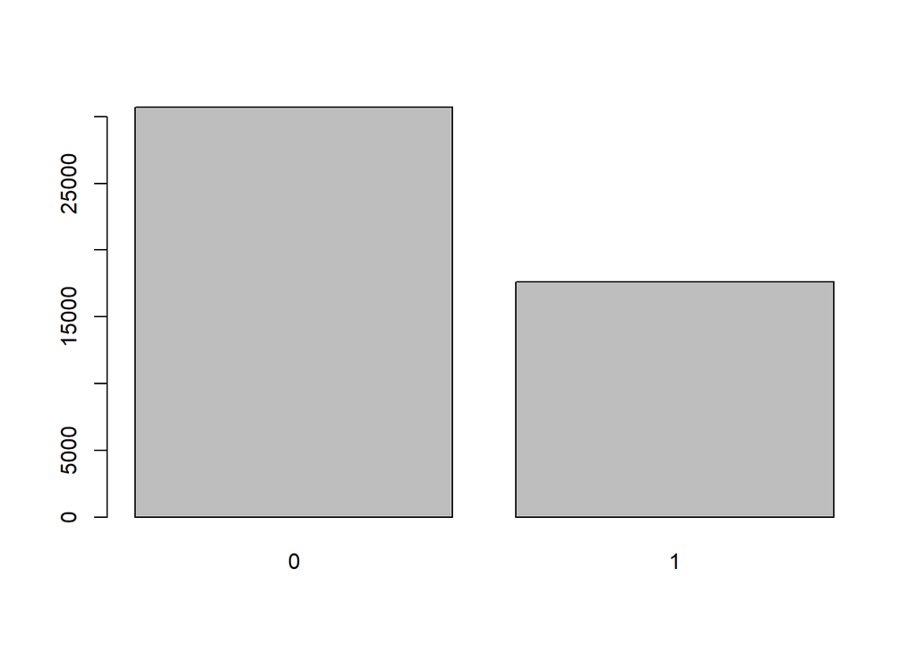

```r
df_sample_tiempo$alto_consumo = as.factor(ifelse(df_sample_tiempo["meter_reading"]>=100, 1, 0))
barplot(table(df_sample_tiempo$alto_consumo))
```

```r
y = df_sample_tiempo$alto_consumo
variables_x <- c("air_temperature", "wind_speed", "square_feet", "primary_use")
x = df_sample_tiempo[variables_x]
```

```r
modelo <- C50::C5.0(x,y,rules=TRUE, )
# summary(modelo)
```

Tras la aplicación de un modelo de árbol de clasificación, se pueden obtener numerosas reglas de asosiación entre valores. Algún ejemplo de las reglas que salen son las siguientes:

Rule 132: (17, lift 2.6)

```
wind_speed > 4.1

square_feet > 283000

square_feet <= 288800

primary_use = Education

->  class 1  [0.947]
```

Rule 133: (35/1, lift 2.6)

```
square_feet > 11143

square_feet <= 13728

primary_use = Healthcare

->  class 1  [0.946]
```

**Nota**: No se han imprimido todas las reglas resultantes del árbol de decisión porque salían muchas y superaba el número de páginas que ha de contener la memoria de la práctica

- Rule 132: Si el uso es para educación y tiene entre 283000 y 288800 pies cuadrados y la velocidad del aire superior a 4.1 m/s entonces asigna a alto consumo con una confianza del 94.7%.
- Rule 133: Si el uso es para sanidad y tiene entre 11143 y 13728 se clasifica en alto consumo con una confianza del 94.6%

# 5 Conclusiones

Concluyendo, se ha podido realizar un análisis previo acerca del consumo energético en función de distintos parámetros que pueden ayudar a las organizaciones y a las personas a ser más conscientes del consumo energético que generan para así hacer este mundo más sostenible.